# Data loading and cleaning - BRFSS

Riccardo Gasparini | Gianluca Michelon | Elisa Pascon | Samuele Pasin

# Research question

> What demographic, socioeconomic and behavioral factors predict participation in preventive cancer screening?

### Source

Dataset: https://www.cdc.gov/brfss/annual_data/annual_2024.html

## Data loading

```r
brfss_complete <- read.xport('BRFSS_2024.XPT')

sprintf("BRFSS data have %d records and %d number of variables.",
        nrow(brfss_complete),
        ncol(brfss_complete))
```

```
## [1] "BRFSS data have 457670 records and 301 number of variables."
```

```r
brfss_complete[1:5, 1:10] # just to get familiar with the dataset
```

```
##   X_STATE FMONTH    IDATE IMONTH IDAY IYEAR DISPCODE      SEQNO     X_PSU
## 1       1      2 02282024     02   28  2024     1100 2024000001 2.024e+09
## 2       1      2 02212024     02   21  2024     1100 2024000002 2.024e+09
## 3       1      2 02212024     02   21  2024     1100 2024000003 2.024e+09
## 4       1      2 02282024     02   28  2024     1100 2024000004 2.024e+09
## 5       1      2 02212024     02   21  2024     1100 2024000005 2.024e+09
##   CTELENM1
## 1        1
## 2        1
## 3        1
## 4        1
## 5        1
```

### Interesting variables

#### Demographic features

- `_STATE`: US State
- `_AGE_G`: Six-level imputed age category
- `_SEX`: Sex variable
- `_RACE`: Race/ethnicity categories
- `MARITAL`: marital status
- `VETERAN3`: Have you ever served on active duty in the United States Armed Forces, either in the regular military or in a National Guard or military reserve unit?

#### Cancer screening participation

Absolute answers:

- `CERVSCRN`: Have you ever had a cervical cancer screening test?
  - `CRVCLPAP`: At your most recent cervical cancer screening, did you have a Pap test?
  - `CRVCLHPV`: At your most recent cervical cancer screening, did you have an H.P.V. test?
- `HADMAM`: Have you ever had a mammogram?
- `HADSIGM4`: Colonoscopy and sigmoidoscopy are exams to check for colon cancer. Have you ever had either of these exams?
- `SMALSTOL`: One stool test uses a special kit to obtain a small amount of stool at home and returns the kit to the doctor or the lab. Have you ever had this test?
- `LCSCTSC1`: Have you ever had a CT or CAT scan of your chest area?
- `PSATEST1`: Have you ever had a P.S.A. test?

Including recency:

- `_RFPAP37`: [combined] Female respondents with and intact cervix, aged 21-65, who have had a pap test in the past three years
- `_PAPHPV1`: [combined] Female respondents with an intact cervix, aged 21-65 that have had a pap test in last 3 years or aged 30-65 that have had an HPV test in last 5 years
- `_HPV5YR1`: [combined] Female respondents with and intact cervix, aged 30-65, who have had an HPV test in the past five years
- `_RFMAM23`: Women respondents aged 40+ who have had a mammogram in the past two years
- `_MAM402Y`: Women respondents aged 40-74 who have had a mammogram in the past two years

#### Socioeconomic factors

- `_INCOMG1`: Income categories (better grouping)
- `_EDUCAG`: Level of education completed (better grouping) [alternative `EDUCA`]
- `EMPLOY1`: Employment status
- `RENTHOM1`: Do you own or rent your home?
- [maybe too complicated to include them] `FOODSTMP` / `SDHFOOD1` / `SDHBILLS` / `SDHUTILS` / `SDHTRNSP`: food stamps, food insecurity, unable to pay bills, utility cutoff, transportation barriers

#### Insurance coverage

- `_HLTHPL2`: Adults who had some form of health insurance
  - `_HCVU654`: Respondents aged 18-64 who have any form of health insurance
- `PERSDOC3`: Do you have one person or a group of doctors that you think of as your personal health care provider?
- `MEDCOST1`: Was there a time in the past 12 months when you needed to see a doctor but could not because you could not afford it?

#### Behavioural

- `_RFSMOK3`: Adults who are current smokers
- `EXERANY2`: During the past month, other than your regular job, did you participate in any physical activities or exercises such as running, calisthenics, golf, gardening, or walking for exercise?
- `_BMI5`: BMI (continuous)
- `_RFDRHV9`: Heavy drinkers (adult men having more than 14 drinks per week and adult women having more than 7 drinks per week)

#### Other

- `HADHYST2`: Have you had a hysterectomy? (to exclude from cervical screening)

#### Weights and data

- `_PSU`: Primary Sampling Unit (Equal to Annual Sequence Number)
- `_LLCPWT`: Final weight assigned to each respondent: Land-line and cell-phone data (Raking derived weight)
- `_STSTR`: Sample Design Stratification Variable

```r
# to be refined
sel_variables <- c(
  "X_PSU", "X_STSTR", "X_LLCPWT", # Weights
  "X_STATE", "X_AGE_G", "X_SEX", "X_RACE", "MARITAL", "VETERAN3", # Demographics
  "CERVSCRN", "CRVCLPAP", "CRVCLHPV", "HADMAM", "HADSIGM4", # Cancer screening (absolute)
  "SMALSTOL", "LCSCTSC1", "PSATEST1", "HADHYST2",
  "X_RFPAP37", "X_PAPHPV1", "X_HPV5YR1", "X_RFMAM23", "X_MAM402Y", # Cancer screening (recency / combined)
  "X_INCOMG1", "X_EDUCAG", "EMPLOY1", "RENTHOM1", # Socioeconomic
  "X_HLTHPL2", "X_HCVU654", "PERSDOC3", "MEDCOST1", # Insurance
  "X_RFSMOK3", "EXERANY2", "X_BMI5", "X_RFDRHV9" # Behavioral
)

brfss24 <- brfss_complete %>%
  select(any_of(sel_variables))
```

### Data cleaning

```r
sub_labels <- c("9"  = "Connecticut", "23" = "Maine", "25" = "Massachusetts", "33" = "New Hampshire", "44" = "Rhode Island", "50" = "Vermont")

sub_codes <- names(sub_labels)

# Filter the dataset
brfss24_sub <- brfss24 %>%
  filter(X_STATE %in% sub_codes)

sprintf("After subsetting, the dataset presents %d records and %d number of variables.",
        nrow(brfss24_sub),
        ncol(brfss24_sub))
```

```
## [1] "After subsetting, the dataset presents 47810 records and 35 number of variables."
```

Cleaning and re-levelling the data:

```r
brfss24_sub <- brfss24_sub %>%
  # transforming 7, 9, 77 and 99 values into NAs
  mutate(across(
    # except for variables where those values mean something
    .cols = c(where(is.numeric), where(is.character),
              -X_RACE, -EMPLOY1, -X_STATE, -X_INCOMG1),
    .fns = ~ .x %>%
      na_if(7) %>%
      na_if(9) %>%
      na_if(77) %>%
      na_if(99)
  )) %>%
  mutate(
    X_STATE = factor(
      as.character(X_STATE),
      levels = sub_codes, # hidden chunk in knitted file
      labels = sub_labels
    ),
    X_SEX = factor(
      X_SEX,
      levels = c(1, 2),
      labels = c("Male", "Female")
    ),
    MARITAL = factor(
      MARITAL,
      levels = 1:6,
      labels = c(
        "Married",
        "Divorced",
        "Widowed",
        "Separated",
        "Never married",
        "Unmarried couple"
      )
    ),
    VETERAN3 = factor(
      VETERAN3,
      levels = c(1, 2),
      labels = c(1, 0)
    ),
    X_AGE_G = factor(
      X_AGE_G,
      levels = 1:6,
      labels = c(
        "Age 18 to 24",
        "Age 25 to 34",
        "Age 35 to 44",
        "Age 45 to 54",
        "Age 55 to 64",
        "Age 65 or older"
      ),
      ordered = TRUE
    ),
    X_INCOMG1 = factor(
      X_INCOMG1,
      levels = 1:7,
      labels = c(
        "<15k",
        "15–25k",
        "25–35k",
        "35–50k",
        "50–100k",
        "100–200k",
        "200k+"
      )
    ),

    X_EDUCAG = factor(X_EDUCAG, ordered = TRUE),
    EMPLOY1  = factor(EMPLOY1),
    RENTHOM1 = factor(RENTHOM1),
    X_HLTHPL2 = factor(
      X_HLTHPL2,
      levels = c(1, 2),
      labels = c("Insured", "Not insured")
    ),
    PERSDOC3 = factor(
      PERSDOC3,
      levels = c(1, 2, 3),
      labels = c(
        "Yes, one",
        "Yes, more than one",
        "No"
      )
    ),
    MEDCOST1 = factor(
      MEDCOST1,
      levels = c(1, 2),
      labels = c(1, 0)
    ),
    X_HCVU654 = factor(
      X_HCVU654,
      levels = c(1, 2),
      labels = c(1, 0)
    ),
    X_RFSMOK3 = factor(X_RFSMOK3),
    EXERANY2 = factor(
      EXERANY2,
      levels = c(1, 2),
      labels = c(1, 0)
    ),
    X_RFDRHV9 = factor(X_RFDRHV9),
    X_BMI5 = as.numeric(X_BMI5) / 100,
    X_RACE = factor(
      X_RACE,
      levels = 1:8,
      labels = c(
        "White only, non-Hispanic",
        "Black only, non-Hispanic",
        "American Indian or Alaskan Native only, non-Hispanic",
        "Asian only, non-Hispanic",
        "Native Hawaiian or other Pacific Islander only, non-Hispanic",
        "Other race only, non-Hispanic",
        "Multiracial, non-Hispanic",
        "Hispanic"
      )
    ),
    CERVSCRN = factor(
      CERVSCRN,
      levels = c(1, 2),
      labels = c(1, 0)
    ),
    CRVCLPAP = factor(
      CRVCLPAP,
      levels = c(1, 2),
      labels = c(1, 0)
    ),
    CRVCLHPV = factor(
      CRVCLHPV,
      levels = c(1, 2),
      labels = c(1, 0)
    ),
    X_RFPAP37 = factor(
      X_RFPAP37,
      levels = c(1, 2),
      labels = c(
        "Had PAP test in last 3 years",
        "Had PAP test more than 3 years ago or have not had one"
      )
    ),
    X_PAPHPV1 = factor(
      X_PAPHPV1,
      levels = c(1, 2),
      labels = c(
        "Had PAP test in last 3 years or HPV test in last 5 years",
        "Have not had PAP test in last 3 years and HPV test in last 5 years"
      )
    ),
    X_HPV5YR1 = factor(
      X_HPV5YR1,
      levels = c(1, 2),
      labels = c(
        "Had HPV test in last 5 years",
        "Had HPV test more than 5 years ago or have not had one"
      )
    ),
    HADMAM = factor(
      HADMAM,
      levels = c(1, 2),
      labels = c(1, 0)
    ),
    X_RFMAM23 = factor(
      X_RFMAM23,
      levels = c(1, 2),
      labels = c(1, 0)
    ),
    X_MAM402Y = factor(
      X_MAM402Y,
      levels = c(1, 2),
      labels = c(1, 0)
    ),
    HADSIGM4 = factor(
      HADSIGM4,
      levels = c(1, 2),
      labels = c(1, 0)
    ),
    SMALSTOL = factor(
      SMALSTOL,
      levels = c(1, 2),
      labels = c(1, 0)
    ),
    LCSCTSC1 = factor(
      LCSCTSC1,
      levels = c(1, 2),
      labels = c(1, 0)
    ),
    PSATEST1 = factor(
      PSATEST1,
      levels = c(1, 2),
      labels = c(1, 0)
    )

  )
```

Creating a composite any-screening indicator (1 = participated in at least one relevant screening, 0 = none) for modelling. We also keep sex-stratified outcomes for deeper models.

```r
brfss24_sub <- brfss24_sub %>%
  mutate(
    # composite: any screening
    any_screening = factor(case_when(if_any(
      c(CERVSCRN, HADMAM, HADSIGM4, SMALSTOL, PSATEST1, LCSCTSC1),
      ~ !is.na(.) & . == 1L # whether the value is not missing or it is equal to 1
    ) ~ 1L, TRUE ~ 0L)),
    # mammography among women only (excluding those with hysterectomy, see below)
    mam_women = factor(if_else(
      X_SEX == "Female",
      if_else(HADMAM == "Yes", 1L, 0L, missing = NA_integer_),
      NA_integer_ # males get an NA and not a 0, since they must not be coded as "didn't get screened"
    ), levels = c(0, 1)),
    # cervical screening: restrict to women without hysterectomy
    cerv_screen = factor(case_when(
      X_SEX == "Female" & (is.na(HADHYST2) | HADHYST2 == "No") &
        CERVSCRN == "Yes"  ~ 1L,
      X_SEX == "Female" & (is.na(HADHYST2) | HADHYST2 == "No") &
        CERVSCRN == "No"   ~ 0L,
      TRUE ~ NA_integer_ # men and women with hysterectomy
    ))
  )
```

Converting the dataset into a survey design object:

```r
brfss.design <- brfss24_sub %>%
  as_survey_design(
    ids = X_PSU,
    weights = X_LLCPWT,
    strata = X_STSTR,
    nest = TRUE
  )

# in the case of variables (State?) having just 1 PSU, to avoid calculation errors:
options(survey.lonely.psu = "adjust")
```

### Taking a glimpse of what the data looks like

```r
glimpse(brfss.design$variables)
```

```
## Rows: 47,810
## Columns: 38
## $ X_PSU         <dbl> 2.024e+09, 2.024e+09, 2.024e+09, 2.024e+09, 2.024e+09, 2…
## $ X_STSTR       <dbl> 91011, 91011, 91011, 91011, 91011, 91011, 91011, 91011, …
## $ X_LLCPWT      <dbl> 769.85481, 2335.93729, 363.02710, 1136.39961, 879.19813,…
## $ X_STATE       <fct> Connecticut, Connecticut, Connecticut, Connecticut, Conn…
## $ X_AGE_G       <ord> Age 55 to 64, Age 65 or older, Age 65 or older, Age 65 o…
## $ X_SEX         <fct> Female, Female, Female, Female, Female, Female, Female, …
## $ X_RACE        <fct> "White only, non-Hispanic", "White only, non-Hispanic", …
## $ MARITAL       <fct> Married, Widowed, Married, Married, Never married, Marri…
## $ VETERAN3      <fct> 0, 0, 0, 0, 0, 0, 0, 0, 0, 0, 1, 0, 0, 0, 0, 0, 0, 0, 1,…
## $ CERVSCRN      <fct> 1, 1, 1, NA, 1, 1, 1, 1, 0, NA, NA, NA, 0, 1, 1, 1, NA, …
## $ CRVCLPAP      <fct> 1, 1, 1, NA, 1, 1, 1, 1, NA, NA, NA, NA, NA, 1, 1, 0, NA…
## $ CRVCLHPV      <fct> 0, 0, 0, NA, 0, NA, NA, 0, NA, NA, NA, NA, NA, 1, 0, 1, …
## $ HADMAM        <fct> 1, 1, 1, 1, 1, 1, 1, 1, 1, NA, NA, NA, 1, 1, 1, 1, 1, 1,…
```

[output cut: 25 more lines]

Summary:

```r
brfss.design %>%
  tbl_svysummary(
    include  = c(X_AGE_G, X_SEX, X_EDUCAG, X_INCOMG1, X_HLTHPL2),
    label    = list(
      X_AGE_G   ~ "Age group",
      X_SEX     ~ "Sex",
      X_EDUCAG  ~ "Education",
      X_INCOMG1 ~ "Household income",
      X_HLTHPL2 ~ "Health insurance"
    ),
    statistic = list(all_categorical() ~ "{p}% ({n_unweighted})")
  ) %>%
  modify_caption("**Weighted demographic characteristics, BRFSS 2024**")
```

**Weighted demographic characteristics, BRFSS 2024**

| **Characteristic** | **N = 12,413,605**<sup>1</sup> |
| --- | --- |
| Age group |  |
| Age 18 to 24 | 12% (2,348) |
| Age 25 to 34 | 16% (4,576) |
| Age 35 to 44 | 16% (5,661) |
| Age 45 to 54 | 15% (6,085) |
| Age 55 to 64 | 17% (9,347) |
| Age 65 or older | 25% (19,793) |
| Sex |  |
| Male | 49% (22,611) |
| Female | 51% (25,199) |
| Education |  |
| 1 | 8.5% (2,081) |
| 2 | 26% (10,773) |
| 3 | 26% (10,968) |
| 4 | 39% (23,722) |
| Unknown | 80,889 |
| Household income |  |
| <15k | 4.9% (1,796) |
| 15–25k | 7.2% (3,185) |
| 25–35k | 8.8% (3,852) |
| 35–50k | 9.9% (4,298) |
| 50–100k | 28% (11,833) |
| 100–200k | 27% (9,537) |
| 200k+ | 14% (3,878) |
| Unknown | 2,792,776 |
| Health insurance |  |
| Insured | 95% (44,237) |
| Not insured | 4.8% (1,693) |
| Unknown | 658,628 |

<sup>1</sup> % (n (unweighted))

```r
# screening_vars <- c("CERVSCRN", "CRVCLPAP", "HADMAM", "HADSIGM4", "SMALSTOL", "LCSCTSC1", "PSATEST1")
#
# screen_labels <- c(
#   CERVSCRN = "Cervical cancer screening (ever)",
#   CRVCLPAP = "Pap test (ever)",
#   HADMAM   = "Mammogram (ever)",
#   HADSIGM4 = "Colonoscopy/sigmoidoscopy (ever)",
#   SMALSTOL = "Stool test (ever)",
#   LCSCTSC1 = "Chest CT scan (ever)",
#   PSATEST1 = "PSA test (ever)"
# )

brfss.design %>%
  tbl_svysummary(
    include   = c(CERVSCRN, CRVCLPAP, HADMAM, HADSIGM4, SMALSTOL, LCSCTSC1, PSATEST1),
    value     = list(
      CERVSCRN ~ "1",
      CRVCLPAP ~ "1",
      HADMAM   ~ "1",
      HADSIGM4 ~ "1",
      SMALSTOL ~ "1",
      LCSCTSC1 ~ "1",
      PSATEST1 ~ "1"
    ),
    label = list(
      CERVSCRN ~ "Cervical cancer screening (ever)",
      CRVCLPAP ~ "Pap test (ever)",
      HADMAM   ~ "Mammogram (ever)",
      HADSIGM4 ~ "Colonoscopy/sigmoidoscopy (ever)",
      SMALSTOL ~ "Stool test (ever)",
      LCSCTSC1 ~ "Chest CT scan (ever)",
      PSATEST1 ~ "PSA test (ever)"
    ),
    # BRFSS weights each respondent to represent a portion of the US population,
    # so one respondent might represent ~5000 people (hence the huge number)
    statistic  = list(all_categorical() ~ "{p}% ({n_unweighted})"),
    digits     = list(all_categorical() ~ c(1, 0)),
    missing    = "no"
  ) %>%
  modify_caption("**Survey-weighted screening participation, BRFSS 2024**")
```

**Survey-weighted screening participation, BRFSS 2024**

| **Characteristic** | **N = 12,413,605**<sup>1</sup> |
| --- | --- |
| Cervical cancer screening (ever) | 79.2% (19,643) |
| Pap test (ever) | 93.6% (17,593) |
| Mammogram (ever) | 68.0% (19,326) |
| Colonoscopy/sigmoidoscopy (ever) | 80.1% (27,265) |
| Stool test (ever) | 76.1% (5,476) |
| Chest CT scan (ever) | 37.5% (17,497) |
| PSA test (ever) | 45.7% (1,167) |

<sup>1</sup> % (n (unweighted))

## Exploratory analysis

### Socioeconomic features

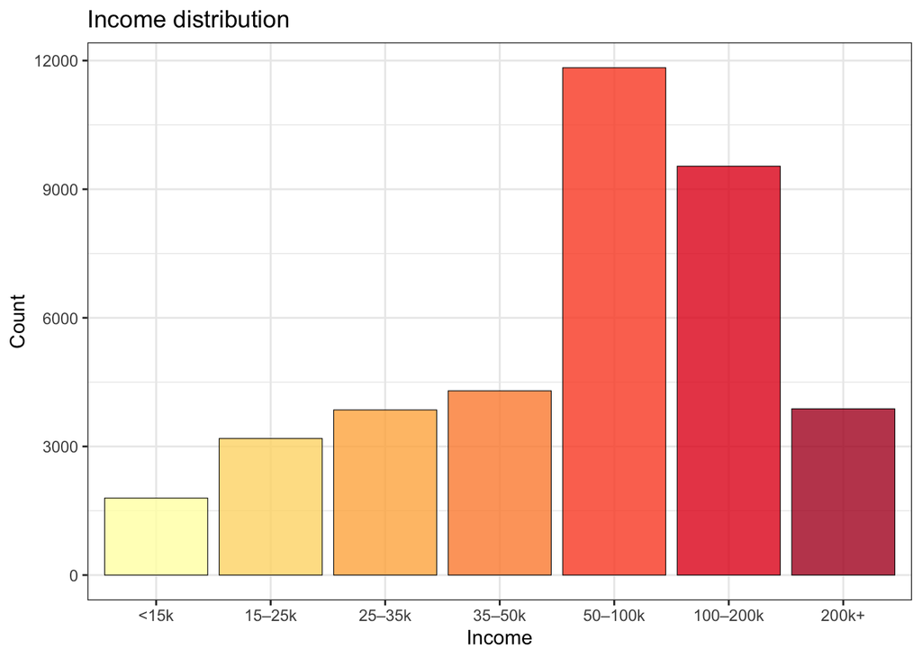

```r
ggplot(brfss24_sub %>% drop_na(X_INCOMG1)) +
  geom_bar(
    aes(X_INCOMG1, fill = X_INCOMG1),
    col = "black",
    linewidth = 0.2,
    alpha = .8
  ) +
  labs(x = "Income", y = "Count", title = "Income distribution") +
  scale_fill_brewer(palette = "YlOrRd") +
  theme_bw() +
  theme(legend.position = "none")
```

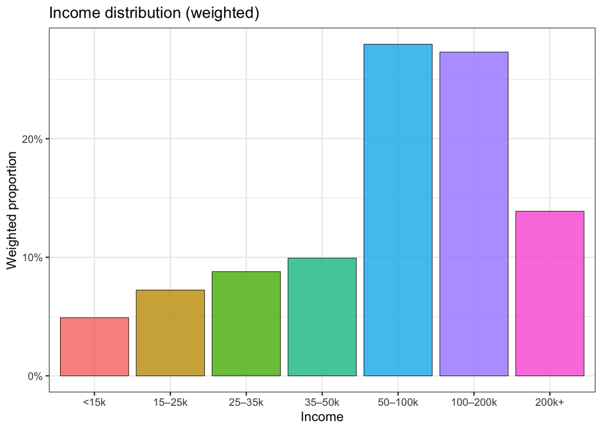

```r
brfss.design %>%
  filter(!is.na(X_INCOMG1)) %>%
  group_by(X_INCOMG1) %>%
  summarise(prop = survey_mean(vartype = "ci")) %>%
  ggplot(aes(X_INCOMG1, prop, fill = X_INCOMG1)) +
  geom_col(col = "black",
           linewidth = 0.2,
           alpha = 0.8) +
  scale_y_continuous(labels = percent_format()) +
  labs(x = "Income", y = "Weighted proportion", title = "Income distribution (weighted)") +
  theme_bw() +
  theme(legend.position = "none")
```

## References

- https://ikwak2.github.io/tutorials/BRFSS/BRFSS.html